# R Notebook

# XGBoost with Resampled dataset

```r
# Install and load required packages
if (!require("ROSE")) install.packages("ROSE", dependencies = TRUE)
if (!require("xgboost")) install.packages("xgboost")
if (!require("caret")) install.packages("caret")
library(ROSE)
library(xgboost)
library(caret)

# Apply ROSE to balance the training data
set.seed(123)  # For reproducibility
balanced_train_data <- ROSE(
  Diabetes_binary ~ .,
  data = train_data,
  seed = 123
)$data

# Check the class distribution after balancing
cat("Class distribution in the balanced training data:\n")
```

```
Class distribution in the balanced training data:
```

```r
print(table(balanced_train_data$Diabetes_binary))
```

```
    0     1
88636 88941
```

```r
# Encode the target variable for XGBoost
balanced_train_data$Diabetes_binary <- as.numeric(balanced_train_data$Diabetes_binary)  # Ensure numeric
test_data$Diabetes_binary <- as.numeric(test_data$Diabetes_binary)

# Prepare the training and testing data
train_matrix <- as.matrix(balanced_train_data[, -which(names(balanced_train_data) == "Diabetes_binary")])
train_labels <- as.numeric(balanced_train_data$Diabetes_binary)

test_matrix <- as.matrix(test_data[, -which(names(test_data) == "Diabetes_binary")])
test_labels <- as.numeric(test_data$Diabetes_binary)

# Create DMatrix for XGBoost
dtrain <- xgb.DMatrix(data = train_matrix, label = train_labels)
dtest <- xgb.DMatrix(data = test_matrix, label = test_labels)

# Set parameters for the XGBoost model
params <- list(
  objective = "binary:logistic",   # Binary classification
  eval_metric = "logloss",        # Log loss metric
  eta = 0.1,                      # Learning rate
  max_depth = 6,                  # Depth of trees
  subsample = 0.8,                # Subsample ratio
  colsample_bytree = 0.8          # Column subsample ratio
)

# Train the XGBoost model
xgb_model <- xgb.train(
  params = params,
  data = dtrain,
  nrounds = 100,                       # Number of boosting rounds
  watchlist = list(train = dtrain),    # Monitor training performance
  print_every_n = 10                   # Print progress every 10 rounds
)
# Predict on the test dataset
predictions <- predict(xgb_model, dtest)

# Convert probabilities to binary labels
predicted_labels <- ifelse(predictions > 0.5, 1, 0)

# Evaluate the model using confusion matrix
conf_matrix <- confusionMatrix(as.factor(predicted_labels), as.factor(test_labels))

# Print evaluation metrics
print(conf_matrix)
```

```
Confusion Matrix and Statistics

          Reference
Prediction     0     1
         0  6187 10319
         1  4416 55181

               Accuracy : 0.8064
                 95% CI : (0.8036, 0.8092)
    No Information Rate : 0.8607
    P-Value [Acc > NIR] : 1

                  Kappa : 0.3454

 Mcnemar's Test P-Value : <2e-16

            Sensitivity : 0.5835
            Specificity : 0.8425
         Pos Pred Value : 0.3748
         Neg Pred Value : 0.9259
             Prevalence : 0.1393
         Detection Rate : 0.0813
   Detection Prevalence : 0.2169
      Balanced Accuracy : 0.7130

       'Positive' Class : 0
```

```r
# Feature importance
importance <- xgb.importance(feature_names = colnames(train_matrix), model = xgb_model)
print(importance)
```

| Feature | Gain | Cover | Frequency |
| --- | --- | --- | --- |
| CholCheck | 0.2681617703 | 0.1534948458 | 0.12524119 |
| HighBP | 0.1249249215 | 0.0322941286 | 0.02788984 |
| HeartDiseaseorAttack | 0.1132504294 | 0.1080307681 | 0.10068409 |
| Stroke | 0.0998308394 | 0.1068724353 | 0.10962989 |
| DiffWalk | 0.0835774012 | 0.0878653862 | 0.07367129 |
| GenHlth | 0.0719828928 | 0.0453903545 | 0.04437818 |
| HvyAlcoholConsump | 0.0511200525 | 0.0815159910 | 0.07595159 |
| BMI | 0.0373886073 | 0.0482784938 | 0.04665848 |
| Age | 0.0327042288 | 0.0470383378 | 0.05437643 |
| HighChol | 0.0292868050 | 0.0267888479 | 0.02788984 |

[output cut: 11 more lines]

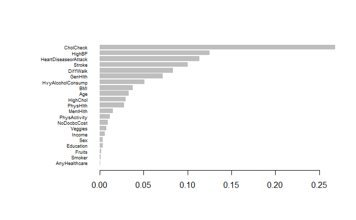

```r
# Plot feature importance
xgb.plot.importance(importance)
```

## Results:

1. Class Distribution in Balanced Training Data: After applying ROSE, the training data is balanced with almost equal numbers of 0 (non-diabetic) and 1 (diabetic) cases:

Class 0: 88,636 Class 1: 88,941

This addresses the class imbalance issue and helps the model learn equally from both classes.

Predicted 0: 6,187 cases correctly identified as 0 (true negatives). 10,319 cases wrongly identified as 0 (false negatives).

4. Evaluation Metrics:

Accuracy: 80.64% of predictions are correct. Indicates overall performance but is not sufficient for imbalanced data.

Balanced Accuracy: 71.30%: The average of sensitivity and specificity. Better reflects performance on imbalanced data compared to raw accuracy.

Kappa: 0.3454: Indicates moderate agreement between predictions and true labels, showing improvement from earlier models.

5. McNemar’s Test: P-value < 2e-16: Indicates a significant difference between the types of errors (false positives vs. false negatives).

###How the Results Improved From Previous Models: